# tDCS1

Effects of tDCS on metacognition in perceptual judgment

cn

2021-06-16

```r
set.seed(12345) # for reproducibility

pacman::p_load(tidyverse, knitr, psych, ggpubr)
pacman::p_load(afex, emmeans)
pacman::p_load_gh("thomasp85/patchwork", "RLesur/klippy", "craddm/metaSDT")

source('HmiscHelper.R')
# 210615. Rmisc::summarySEwithin은 mean of normalized를 리턴.
# 따라서 패키지를 쓰지 않고 위 R파일에 정의된, 같은 이름의 함수를 쓴다.
# Rmisc::summarySEwithin과 달리 정규화하지 않은 평균도 제공한다.
# dplyr와 충돌하지 않도록 plyr 함수들을 직접 부르도록 수정하였다.
# http://www.cookbook-r.com/Graphs/Plotting_means_and_error_bars_(ggplot2)/
# See also: https://github.com/ccoolbaugh/FrontPhysiol_Coolbaugh_Cooling_Protocol

options(knitr.kable.NA = '')
options(dplyr.summarise.inform=FALSE) # suppress warning in regards to regrouping
set_sum_contrasts() # see Singmann & Kellen (2020)

klippy::klippy()
```

```r
## Plots

# stat summary plot to 25% quartile and 75% quartile: https://bit.ly/3iFpV07
single_hori_plot <- function(df, X, xMin, xMax, xBy, xLab){
  df %>% ggplot(aes(x=1, y=X)) +
    geom_violin(width = .9, trim = TRUE) +
    ggbeeswarm::geom_quasirandom(dodge.width = 0.5, color = "blue", size = 3,
                                 alpha = 0.2, show.legend = FALSE) +
    # stat_summary(fun.data = "mean_cl_boot", color = "darkred", size = 1) +
    geom_pointrange(stat = "summary",
                    fun.min = function(z) {quantile(z,0.25)},
                    fun.max = function(z) {quantile(z,0.75)},
                    fun = median, color = "darkred", size = 1) +
    scale_y_continuous(breaks=seq(xMin,xMax,by=xBy)) +
    coord_flip(ylim = c(xMin, xMax), clip = "on") +
    labs(y = xLab) +
    theme_bw(base_size = 18) +
    theme(panel.grid.major = element_blank(),
          panel.grid.minor = element_blank(),
          axis.title.y = element_blank(),
          axis.ticks.y = element_blank(),
          axis.text.y = element_blank(),
          aspect.ratio = .3)
}

plot2x2spaghetti <- function(df, ylabel, yrange){
  df.w <- df %>% pivot_wider(id_cols = c('Group', 'SID'),
                             names_from = 'Session', values_from = V)

  p <- ggplot(data=df, aes(x = Group, y = V, fill = Session)) +
    geom_violin(width = 0.5, trim = TRUE) +
    geom_point(position=position_dodge(0.5),
               color="gray80", size=1.8, show.legend = FALSE) +
    geom_segment(data=filter(df.w, Group=="Real"), inherit.aes = FALSE,
                 aes(x=1-.12, y=filter(df.w, Group=="Real")$Pre,
                     xend=1+.12, yend=filter(df.w, Group=="Real")$Post),
                 color="gray80") +
    geom_segment(data=filter(df.w, Group=="Sham"), inherit.aes = FALSE,
                 aes(x=2-.12, y=filter(df.w, Group=="Sham")$Pre,
                     xend=2+.12, yend=filter(df.w, Group=="Sham")$Post),
                 color="gray80") +
    geom_pointrange(data=summarySEwithin(data = df, measurevar = "V", idvar = "SID",
                                         withinvars = "Session", betweenvars = "Group"),
                    aes(x = Group, ymin = V-ci, ymax = V+ci, group = Session),
                    position = position_dodge(0.5), color = "darkred", size = 1, show.legend = FALSE) +
    scale_fill_manual(values=c("#E69F00", "#56B4E9"),
                      labels=c("Pre", "Post")) +
    labs(x = "Group",
         y = ylabel,
         fill='Session') +
    theme_bw(base_size = 18) +
    theme(panel.grid.major = element_blank(),
          panel.grid.minor = element_blank())

  if(missing(yrange)){
    p
  } else {
    p + coord_cartesian(ylim = yrange, clip = "on")
  }
}


## Excluding Ss
rm_subject <- function(df, rx){
  for (i in rx){
    df <- df %>% filter(SID != i) %>% droplevels()
  }
  cat(sprintf('%d removed & %d left',
              length(unique(rx)),
              length(unique(df$SID))))
  return(df)
}
```

# 1 Behavioral Data

## 1.1 Preview

1~7번 참가자에게는 절반인 240시행만 제시되었다. 26번 참가자는 `pre-tDCS` 세션에서 Type-1 반응을 입력하지 않은 경우가 빈번하여 유효 시행 수가 적었다. 극단값이 있는지 확인하기 위해 기본 요약자료의 분포를 그려보자.

```r
d <- read_csv('metaRDMmain.csv')
##
## ── Column specification ────────────────────────────────────────────────────────
## cols(
##   Group = col_double(),
##   Session = col_double(),
##   SID = col_double(),
##   PracDir = col_double(),
##   Difficulty = col_double(),
##   Trial = col_double(),
##   Staircase = col_double(),
##   MainDir = col_double(),
##   TargLoc = col_double(),
##   Resp = col_double(),
##   Correct = col_double(),
##   Type1RT = col_double(),
##   Conf = col_double(),
##   Type2RT = col_double()
## )

d$Group <- factor(d$Group, levels=c(1,2), labels=c("Real","Sham"))
d$Session <- factor(d$Session, levels=c(1,2), labels=c("Pre","Post"))
d$TargLoc <- factor(d$TargLoc, levels=c(1,2), labels=c("L","R"))
# d$SID <- factor(d$SID)

table(d$Group, d$SID)
##
##          1   2   3   4   5   6   7   8   9  10  11  12  13  14  15  16  17  18
##   Real 240   0   0 240   0 240 240   0   0 480   0 480   0 480   0 480   0   0
##   Sham   0 240 240   0 240   0   0 480 480   0 480   0 480   0 480   0 480 480
##
##         19  20  21  22  23  24  25  26  27  28  29  30  31  32
##   Real 480 480 480   0 480   0 480   0 480   0 480   0 480   0
##   Sham   0   0   0 480   0 480   0 480   0 480   0 480   0 480
table(d$Session, d$SID)
##
##          1   2   3   4   5   6   7   8   9  10  11  12  13  14  15  16  17  18
##   Pre  120 120 120 120 120 120 120 240 240 240 240 240 240 240 240 240 240 240
##   Post 120 120 120 120 120 120 120 240 240 240 240 240 240 240 240 240 240 240
##
##         19  20  21  22  23  24  25  26  27  28  29  30  31  32
##   Pre  240 240 240 240 240 240 240 240 240 240 240 240 240 240
##   Post 240 240 240 240 240 240 240 240 240 240 240 240 240 240

# unique(d$PracDir)
# unique(d$MainDir)
# unique(d$TargLoc)

unique(d$Resp)    # 0_no resp,
## [1] 1 2 0
unique(d$Correct)
## [1] 0 1
unique(d$Conf)    # 0, 6 = no or wrong keys?
## [1] 2 1 3 4 0 6

table(d$Resp, d$SID) # 26번
##
##       1   2   3   4   5   6   7   8   9  10  11  12  13  14  15  16  17  18  19
##   0   5   8   0  21   0   9   1   0  14   2   5  11   0   0   0   3   1   0   2
##   1 112  95 151  95 166 146 149 308 330 251 278 255 281 217 307 389 248 255 252
##   2 123 137  89 124  74  85  90 172 136 227 197 214 199 263 173  88 231 225 226
##
##      20  21  22  23  24  25  26  27  28  29  30  31  32
##   0   2  12   0   0   5   2 106  17   1   0   4   1  13
##   1 366 251 311 274 323 356 295 249 247 292 260 297 260
##   2 112 217 169 206 152 122  79 214 232 188 216 182 207
table(d$Conf, d$SID) # missing cell 많음 --> 2점 평정 변환 필요
##
##       1   2   3   4   5   6   7   8   9  10  11  12  13  14  15  16  17  18  19
##   0   0   1   0   0   0   1   0   0   0   2   0   0   0   0   0   2   1   0   0
##   1  48  37  39  38  65 138  10 163 165  35 160 113  27  10 106 305   0 239 171
##   2  54  21  47  95  55  51  31 106 123 330 129  53  87 159 196 155 153 192 118
##   3  97  58  68  92  40  30 121  84  87 113 105  87 114 308 168  17 320  49 148
##   4  41 121  86  15  79  20  78 127 103   0  86 226 252   2  10   1   5   0  43
##   6   0   2   0   0   1   0   0   0   2   0   0   1   0   1   0   0   1   0   0
##
##      20  21  22  23  24  25  26  27  28  29  30  31  32
##   0   0   0   0   0   0   0   1   8   0   0   0   1   1
##   1 229 291 166 150  99 221 215  17  50 139  78 109  22
##   2  48 136 105 117 145 192 162  69  39  88  41 153 152
##   3  37  52  94 172 209  38  71 349  48 177  39 128 129
##   4 166   1 114  41  27  29  31  37 343  76 322  89 175
##   6   0   0   1   0   0   0   0   0   0   0   0   0   1

# hist(d$Type1RT) # 2초 안에 대부분 반응
# hist(d$Type2RT) # 3초 안에 대부분 반응
# hist(d$Conf)
```

### 1.1.1 % Excluded Trials

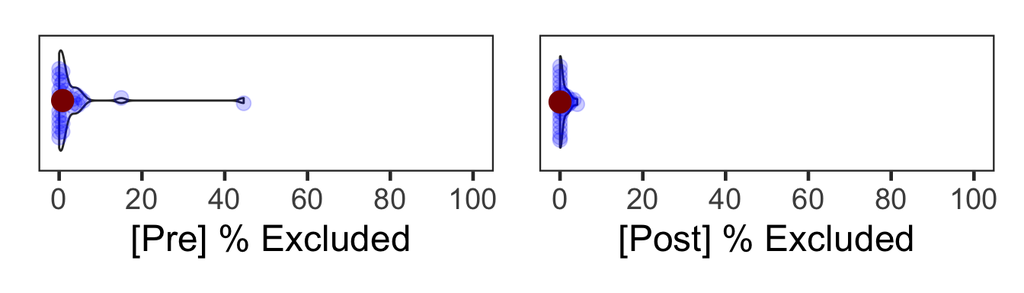

```r
# % excluded trials: 지각반응과 확신도 무반응/잘못된 버튼
d %>% filter(Session == 'Pre') %>%
  mutate(X = ifelse(Resp==0, 1, ifelse((Conf==0)|(Conf==5), 1, 0))) %>%
  group_by(SID) %>%
  summarise(Excl = mean(X)*100) %>%
  ungroup() %>%
  print(n = Inf)
## # A tibble: 32 x 2
##      SID   Excl
##    <dbl>  <dbl>
##  1     1  4.17
##  2     2  3.33
##  3     3  0
##  4     4 15
##  5     5  0
##  6     6  5.83
##  7     7  0.833
##  8     8  0
##  9     9  1.67
## 10    10  0.833
## 11    11  1.25
## 12    12  2.92
## 13    13  0
## 14    14  0
## 15    15  0
## 16    16  1.67
## 17    17  0
## 18    18  0
## 19    19  0.833
## 20    20  0.833
## 21    21  4.58
## 22    22  0
## 23    23  0
## 24    24  0.417
## 25    25  0.833
## 26    26 44.6
## 27    27  5
## 28    28  0
## 29    29  0
## 30    30  0.417
## 31    31  0.833
## 32    32  3.75

F1 <- d %>% filter(Session == 'Pre') %>%
  mutate(X = ifelse(Resp==0, 1, ifelse((Conf==0)|(Conf==5), 1, 0))) %>%
  group_by(SID) %>%
  summarise(Excl = mean(X)*100) %>%
  ungroup() %>%
  single_hori_plot(.$Excl, 0, 100, 20, " [Pre] % Excluded")

F2 <- d %>% filter(Session == 'Post') %>%
  mutate(X = ifelse(Resp==0, 1, ifelse((Conf==0)|(Conf==5), 1, 0))) %>%
  group_by(SID) %>%
  summarise(Excl = mean(X)*100) %>%
  ungroup() %>%
  single_hori_plot(.$Excl, 0, 100, 20, "[Post] % Excluded")

F1 + F2
```

```r
d %>% group_by(Group, Session, SID) %>%
  mutate(X = ifelse(Resp==0, 1, ifelse((Conf==0)|(Conf==5), 1, 0))) %>%
  summarise(N = sum(X)) %>%
  ungroup() %>%
  aov_ez(id = 'SID', dv = 'N', within = 'Session', between = 'Group',
         anova_table = list(es = "pes")) %>%
  anova() %>%
  kable(digits = 4, caption = '% Excluded Trials')
```

% Excluded Trials

|  | num Df | den Df | MSE | F | ges | Pr(>F) |
| --- | --- | --- | --- | --- | --- | --- |
| Group | 1 | 30 | 183.2448 | 0.3603 | 0.0059 | 0.5529 |
| Session | 1 | 30 | 186.1740 | 2.0163 | 0.0328 | 0.1659 |
| Group:Session | 1 | 30 | 186.1740 | 0.1552 | 0.0026 | 0.6964 |

제외될 시행 비율의 조건간 차이는 없었다. 아직 가외치 참가자들을 제외하기 전이므로, 최종 분석에 사용할 자료를 대상으로 이 분석을 다시 해야 한다.

### 1.1.2 Mean Confidence

조건간 확신도 평균의 차이는 없었다.

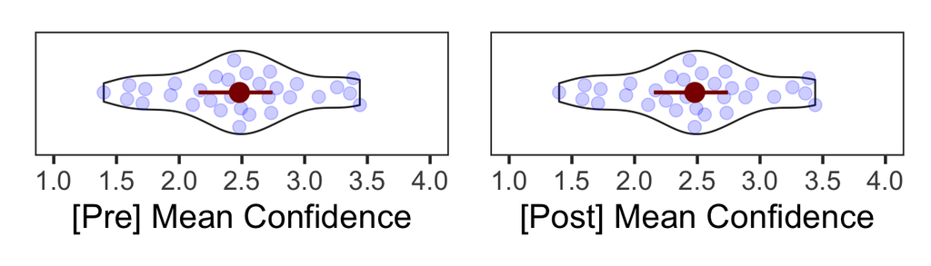

```r
# Confidence: 지각반응과 확신도 모두 바른 버튼.
F1 <- d %>% filter(Session == 'Pre') %>%
  filter(Resp > 0, Conf > 0, Conf < 5) %>%
  group_by(SID) %>%
  summarise(M = mean(Conf)) %>%
  ungroup() %>%
  single_hori_plot(.$M, 1, 4, 0.5, "[Pre] Mean Confidence")

F2 <- d %>% filter(Session == 'Pre') %>%
  filter(Resp > 0, Conf > 0, Conf < 5) %>%
  group_by(SID) %>%
  summarise(M = mean(Conf)) %>%
  ungroup() %>%
  single_hori_plot(.$M, 1, 4, 0.5, "[Post] Mean Confidence")

F1 + F2
```

```r
d %>% filter(Resp > 0, Conf > 0, Conf < 5) %>%
  group_by(Group, Session, SID) %>%
  summarise(M = mean(Conf)) %>%
  ungroup() %>%
  aov_ez(id = 'SID', dv = 'M', within = 'Session', between = 'Group',
         anova_table = list(es = "pes")) %>%
  anova() %>%
  kable(digits = 4, caption = 'Mean Confidence')
```

Mean Confidence

|  | num Df | den Df | MSE | F | ges | Pr(>F) |
| --- | --- | --- | --- | --- | --- | --- |
| Group | 1 | 30 | 0.5289 | 2.6922 | 0.0764 | 0.1113 |
| Session | 1 | 30 | 0.0448 | 1.4303 | 0.0037 | 0.2411 |
| Group:Session | 1 | 30 | 0.0448 | 0.5368 | 0.0014 | 0.4695 |

### 1.1.3 Perceptual Accuracy

지각판단의 정확도 평균의 차이도 없었다.

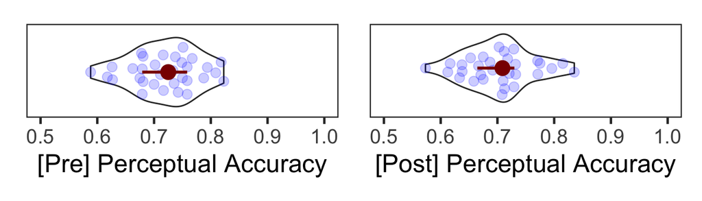

```r
# Perceptual Accuracy: 초반 updown 과정 포함
F1 <- d %>% filter(Session == 'Pre') %>%
  filter(Resp > 0) %>%
  group_by(SID) %>%
  summarise(M = mean(Correct)) %>%
  ungroup() %>%
  single_hori_plot(.$M, 0.5, 1, .1, "[Pre] Perceptual Accuracy")

F2 <- d %>% filter(Session == 'Post') %>%
  filter(Resp > 0) %>%
  group_by(SID) %>%
  summarise(M = mean(Correct)) %>%
  ungroup() %>%
  single_hori_plot(.$M, 0.5, 1, .1, "[Post] Perceptual Accuracy")

F1 + F2
```

```r
d %>% filter(Resp > 0) %>%
  group_by(Group, Session, SID) %>%
  summarise(M = mean(Correct)) %>%
  ungroup() %>%
  aov_ez(id = 'SID', dv = 'M', within = 'Session', between = 'Group',
         anova_table = list(es = "pes")) %>%
  anova() %>%
  kable(digits = 4, caption = 'Perceptual Accuracy')
```

Perceptual Accuracy

|  | num Df | den Df | MSE | F | ges | Pr(>F) |
| --- | --- | --- | --- | --- | --- | --- |
| Group | 1 | 30 | 0.0042 | 0.5330 | 0.0103 | 0.4710 |
| Session | 1 | 30 | 0.0030 | 1.5545 | 0.0210 | 0.2221 |
| Group:Session | 1 | 30 | 0.0030 | 0.8102 | 0.0111 | 0.3752 |

### 1.1.4 Motion Coherence

운동신호 평균의 차이도 없었다.

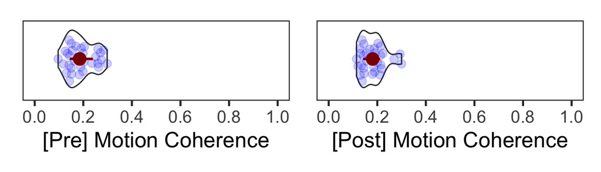

```r
# Motion Coherence
F1 <- d %>% filter(Session == 'Pre') %>%
  filter(Resp > 0) %>%
  group_by(SID) %>%
  summarise(M = mean(Difficulty)) %>%
  ungroup() %>%
  single_hori_plot(.$M, 0, 1, .2, "[Pre] Motion Coherence")

F2 <- d %>% filter(Session == 'Post') %>%
  filter(Resp > 0) %>%
  group_by(SID) %>%
  summarise(M = mean(Difficulty)) %>%
  ungroup() %>%
  single_hori_plot(.$M, 0, 1, .2, "[Post] Motion Coherence")

F1 + F2
```

```r
d %>% filter(Resp > 0) %>%
  group_by(Group, Session, SID) %>%
  summarise(M = mean(Difficulty)) %>%
  ungroup() %>%
  aov_ez(id = 'SID', dv = 'M', within = 'Session', between = 'Group',
         anova_table = list(es = "pes")) %>%
  anova() %>%
  kable(digits = 4, caption = 'Motion Coherence')
```

Motion Coherence

|  | num Df | den Df | MSE | F | ges | Pr(>F) |
| --- | --- | --- | --- | --- | --- | --- |
| Group | 1 | 30 | 0.0041 | 1.3924 | 0.0342 | 0.2473 |
| Session | 1 | 30 | 0.0013 | 1.1062 | 0.0087 | 0.3013 |
| Group:Session | 1 | 30 | 0.0013 | 1.1543 | 0.0090 | 0.2912 |

## 1.2 Staircases

**Perceptual Accuracy**와 **Motion Coherence**가 조건간 다르지 않았다는 결과는 staircase 절차에 의해 난이도가 일정하게 유지되었음을 의미한다. 아래는 각 세션별 staircase 양상을 보여준다.

### 1.2.1 Pre-session

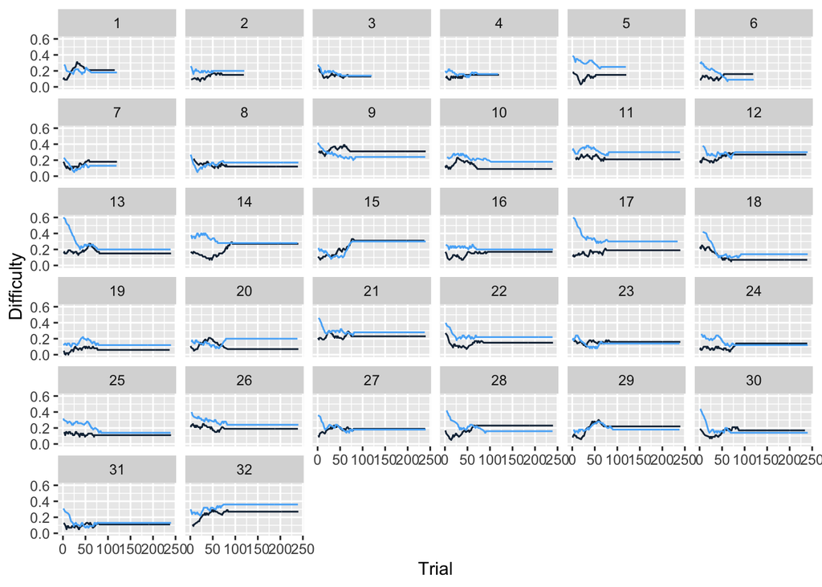

```r
d %>% filter(Session == 'Pre') %>%
  group_by(SID) %>%
  ggplot(aes(x=Trial, y=Difficulty, group=Staircase, color=Staircase)) +
  geom_line(show.legend = FALSE) +
  facet_wrap(~SID)
```

실험을 시작하기 전에 staircase 절차를 통해 참가자별 자극 수준을 확정했는데도 불구하고, `Pre-session` 시작할 때 staircase를 다시 시작하는 경우가 있었다. 문제는 그것이 일관적이지 않았다는 점이다. 가령, 13번과 17번 참가자는 staircase를 다시 시작했고, 19번과 20번 참가자는 이미 조절된 난이도에서 세션을 시작한 것으로 보인다.

### 1.2.2 Post-session

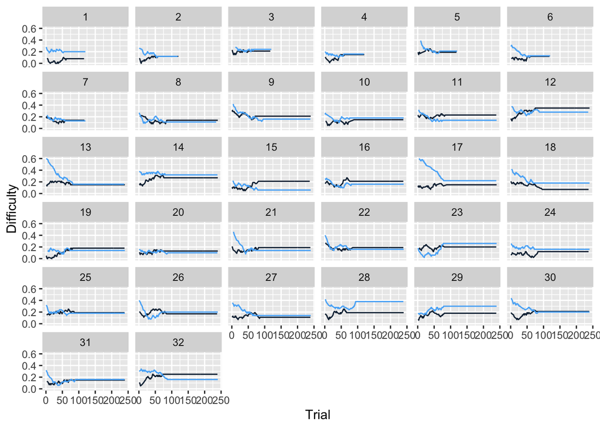

```r
d %>% filter(Session == 'Post') %>%
  group_by(SID) %>%
  ggplot(aes(x=Trial, y=Difficulty, group=Staircase, color=Staircase)) +
  geom_line(show.legend = FALSE) +
  facet_wrap(~SID)
```

`Post-session`에서도 마찬가지였다. 어떤 참가자는 두 개의 staircase가 다른 난이도에서 시작하고, 다른 참가자의 staircase는 비슷한 난이도에서 시작하였다.

## 1.3 Subject Exclusion

`Pre-session`에서 절반 가량 반응하지 않은 26번 참가자를 제외하기로 결정하였다.

```r
d26 <- d %>% filter(SID == 26)
table(d26$Resp, d26$Session) # pre에서 약 50% 무반응
##
##     Pre Post
##   0 106    0
##   1 106  189
##   2  28   51
table(d26$Conf, d26$Session) # pre, post 대부분 1점 평정
##
##     Pre Post
##   0   1    0
##   1 108  107
##   2  57  105
##   3  50   21
##   4  24    7
```

```r
d2 <- rm_subject(d, 26) %>% filter(Resp > 0, Conf > 0, Conf < 5)
```

```
## 1 removed & 31 left
```

# 2 Motion Coherence

Staircase로 수행율이 일정하게 유지되는 동안에 지각판단이 향상되었다면, tDCS 전후로 **motion coherence**가 낮아져야 한다. 경향성을 파악하기 위해, 참가자별 마지막 20시행의 자극수준을 평균하였다. 유의미한 조건간 차이는 없었다.

```r
# 지각수행 측정치로서 마지막 20시행의 motion coherence를 계산했다.
coherence <- d2 %>% group_by(Group, Session, SID) %>%
  nest() %>%
  mutate(last20 = map(data, ~tail(.x, n=20))) %>%
  mutate(V = map(last20, ~mean(.$Difficulty))) %>%
  unnest(V) %>%
  select(Group, Session, SID, V)

coherence %>% aov_ez(id = 'SID', dv = 'V',
                     between = 'Group', within = 'Session') %>%
  anova() %>%
  kable(digits = 4, caption = 'Motion Coherence ANOVA')
```

Motion Coherence ANOVA

|  | num Df | den Df | MSE | F | ges | Pr(>F) |
| --- | --- | --- | --- | --- | --- | --- |
| Group | 1 | 29 | 0.0044 | 0.3151 | 0.0077 | 0.5789 |
| Session | 1 | 29 | 0.0018 | 0.6659 | 0.0066 | 0.4211 |
| Group:Session | 1 | 29 | 0.0018 | 2.7511 | 0.0268 | 0.1080 |

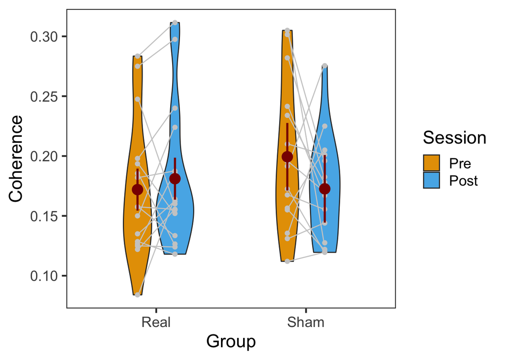

```r
plot2x2spaghetti(coherence, "Coherence")
```

# 3 Confidence

tDCS가 확신 수준에 영향을 끼쳤는지 확인하기 위해 **평균 확신도** 점수를 분석하였다. 분석 결과, 눈에 띄는 효과는 없었다. (참고: 다른 지표들에 비해, 각 참가자의 평균 확신도 점수는 일정하게 유지되는 것으로 보인다. 신뢰구간이 작다.)

```r
confidence <- d2 %>% group_by(Group, Session, SID) %>%
  summarise(V = mean(Conf)) %>%
  ungroup()

confidence %>% aov_ez(id = 'SID', dv = 'V',
                      between = 'Group', within = 'Session') %>%
  anova() %>%
  kable(digits = 4, caption = 'Confidence ANOVA')
```

Confidence ANOVA

|  | num Df | den Df | MSE | F | ges | Pr(>F) |
| --- | --- | --- | --- | --- | --- | --- |
| Group | 1 | 29 | 0.5042 | 3.7472 | 0.1059 | 0.0627 |
| Session | 1 | 29 | 0.0461 | 1.1687 | 0.0034 | 0.2886 |
| Group:Session | 1 | 29 | 0.0461 | 0.3987 | 0.0011 | 0.5327 |

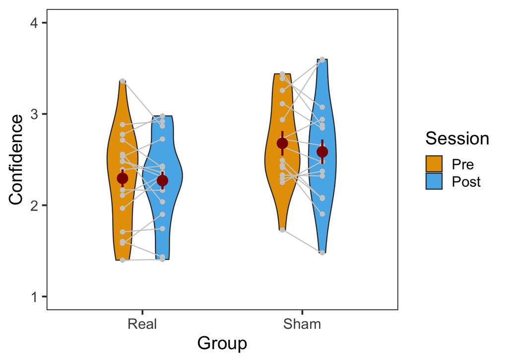

```r
plot2x2spaghetti(confidence, "Confidence", c(1,4))
```

# 4 Matlab MLE Data

[Maniscalco](http://www.columbia.edu/~bsm2105/type2sdt/)의 코드를 사용하여 $d'$, meta-$d'$, M-ratio(meta-$d'/d'$)를 계산하였다. `trials2counts()` 함수와 `fit_meta_d_MLE()` 함수에 입력한 값들은 아래 코드와 같았다. 4점 척도에서 빈도가 0인 경우가 많아서, `fit_meta_d_MLE()` 도움말을 따라 2점 척도로 변환하였다. 여전히 빈도가 0인 점수들이 있으므로, [작은 수](https://bit.ly/3i3DJkE)(adj_f = 1/(length(nR_S1)) = 0.25)를 [모든 값](https://bit.ly/3uwHp0U)에 더해주었다

```matlab
% 원자료: metaRDMmain.csv

stimID = TargLoc - 1;
response = Resp - 1;
rating = Conf;
nRatings = 2;
cellpad = 1; # 확신도 점수 빈도 = 0인 사례를 보정.

[nR_S1, nR_S2] = trials2counts(stimID, response, rating, nRatings, cellpad);

fit = fit_meta_d_MLE(nR_S1, nR_S2);

% 출력자료: tDCS1_estimated.csv
```

```r
mtb2 <- read_csv('tDCS1_estimated_2scale.csv') %>% filter(SID!= 26)
##
## ── Column specification ────────────────────────────────────────────────────────
## cols(
##   `#` = col_double(),
##   SID = col_double(),
##   Group = col_double(),
##   p1da = col_double(),
##   p1meta_da = col_double(),
##   p1M_diff = col_double(),
##   p1M_ratio = col_double(),
##   p1meta_ca = col_double(),
##   p2da = col_double(),
##   p2meta_da = col_double(),
##   p2M_diff = col_double(),
##   p2M_ratio = col_double(),
##   p2meta_ca = col_double()
## )

selectMtb <- function(mtb, V1, V2){
  df <- mtb %>% select(Group, SID, all_of(V1), all_of(V2)) %>%
    pivot_longer(cols = c(all_of(V1), all_of(V2)), names_to = "Session", values_to = "V") %>%
    mutate(Group = fct_recode(as_factor(Group), "Real" = '1', "Sham" = '2')) %>%
    mutate(Session = fct_recode(Session, "Pre" = V1, "Post" = V2))
  return(df)
}
```

## 4.1 Preview

극단값이 있는지 확인하기 위해 기본 요약자료의 분포를 그려보자.

### 4.1.1 Type-1 Accuracy: d’

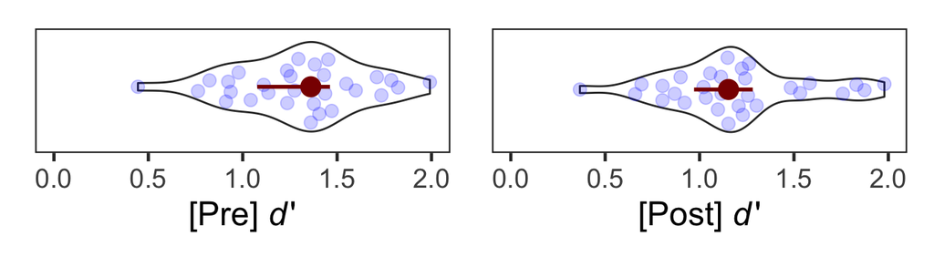

```r
# d'
td <- mtb2 %>% selectMtb('p1da', 'p2da')

F1 <- td %>% filter(Session == 'Pre') %>%
  single_hori_plot(.$V, 0, 2, .5, expression(paste("[Pre] ", italic(d), "'")))
F2 <- td %>% filter(Session == 'Post') %>%
  single_hori_plot(.$V, 0, 2, .5, expression(paste("[Post] ", italic(d), "'")))
F1 + F2
```

### 4.1.2 Type-2 Accuracy: Meta-d’

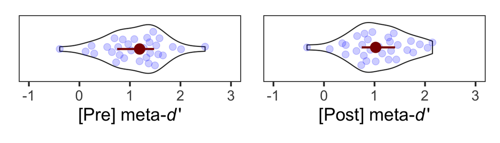

```r
# meta-d'
tm <- mtb2 %>% selectMtb('p1meta_da', 'p2meta_da')

F1 <- tm %>% filter(Session == 'Pre') %>%
  single_hori_plot(.$V, -1, 3, 1, expression(paste("[Pre] meta-", italic(d), "'")))
F2 <- tm %>% filter(Session == 'Post') %>%
  single_hori_plot(.$V, -1, 3, 1, expression(paste("[Post] meta-", italic(d), "'")))
F1 + F2
```

### 4.1.3 M-Ratio (Meta-d’/d’)

`Post-session`에서 $\mu \pm3SD$(빨간 점선)보다 큰 값을 보인 8번 참가자를 가외치로 판정하였다.

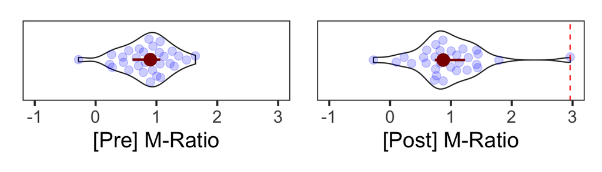

```r
# meta-ratio
tr <- mtb2 %>% selectMtb('p1M_ratio', 'p2M_ratio')

tr %>% filter(Session == 'Pre') %>%
  mutate(lbound = mean(.$V) - 3*sd(.$V),
         ubound = mean(.$V) + 3*sd(.$V)) %>%
  mutate(Outlier = (V < lbound)|(V > ubound)) %>%
  filter(Outlier == TRUE) %>%
  droplevels()
## # A tibble: 0 x 7
## # … with 7 variables: Group <fct>, SID <dbl>, Session <fct>, V <dbl>,
## #   lbound <dbl>, ubound <dbl>, Outlier <lgl>

tr %>% filter(Session == 'Post') %>%
  mutate(lbound = mean(.$V) - 3*sd(.$V),
         ubound = mean(.$V) + 3*sd(.$V)) %>%
  mutate(Outlier = (V < lbound)|(V > ubound)) %>%
  filter(Outlier == TRUE) %>%
  droplevels()
## # A tibble: 1 x 7
##   Group   SID Session     V lbound ubound Outlier
##   <fct> <dbl> <fct>   <dbl>  <dbl>  <dbl> <lgl>
## 1 Sham      8 Post     2.96 -0.754   2.67 TRUE

F1 <- tr %>% filter(Session == 'Pre') %>%
  single_hori_plot(.$V, -1, 3, 1, '[Pre] M-Ratio')
F2 <- tr %>% filter(Session == 'Post') %>%
  single_hori_plot(.$V, -1, 3, 1, '[Post] M-Ratio') +
  geom_hline(yintercept=2.96, linetype='dashed', color='red', size=0.5)
F1 + F2
```

### 4.1.4 M-Difference (Meta-d’ - d’)

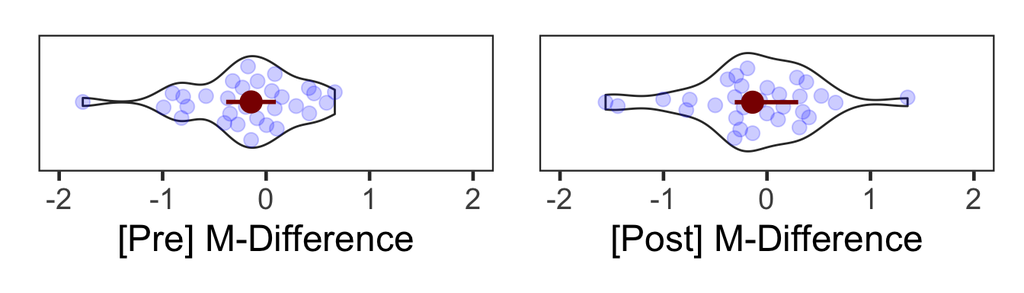

```r
# meta-diff
tf <- mtb2 %>% selectMtb('p1M_diff', 'p2M_diff')

F1 <- tf %>% filter(Session == 'Pre') %>%
  single_hori_plot(.$V, -2, 2, 1, '[Pre] M-Difference')
F2 <- tf %>% filter(Session == 'Post') %>%
  single_hori_plot(.$V, -2, 2, 1, '[Post] M-Difference')
F1 + F2
```

### 4.1.5 Meta-c

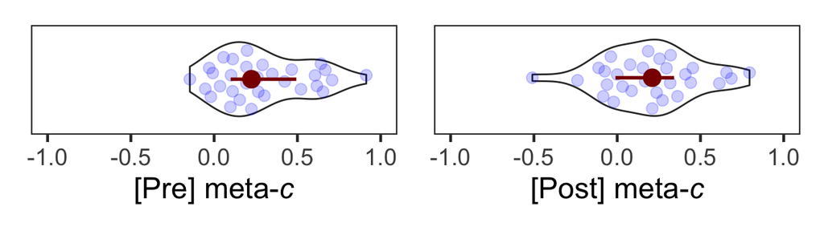

```r
# meta-c
tc <- mtb2 %>% selectMtb('p1meta_ca', 'p2meta_ca')

F1 <- tc %>% filter(Session == 'Pre') %>%
  single_hori_plot(.$V, -1, 1, 0.5, expression(paste("[Pre] meta-", italic(c))))
F2 <- tc %>% filter(Session == 'Post') %>%
  single_hori_plot(.$V, -1, 1, 0.5, expression(paste("[Post] meta-", italic(c))))
F1 + F2
```

## 4.2 Subject Exclusion

참가자 26번과 8번을 최종분석에서 제외하기로 한다(`Real` 집단 16명, `Sham` 집단 14명).

```r
mtb2 <- mtb2 %>% rm_subject(c(8, 26))
```

```
## 2 removed & 30 left
```

# 5 M-Ratio (Meta-d’/d’)

메타인지 효율성 지표에서 이원 상호작용이 유의미하였다. 사후분석에서 `Real` 집단의 메타인지 효율성이 유의미하게 향상되었다.

```r
## Ratio
tr <- mtb2 %>% selectMtb('p1M_ratio', 'p2M_ratio')

tr %>% group_by(Group, Session) %>%
  summarise(M = mean(V)) %>%
  ungroup() %>%
  pivot_wider(names_from = 'Session', values_from = 'M') %>%
  kable(digits = 4, caption = 'Mean M-Ratio')
```

Mean M-Ratio

| Group | Pre | Post |
| --- | --- | --- |
| Real | 0.6886 | 0.9027 |
| Sham | 1.0169 | 0.8826 |

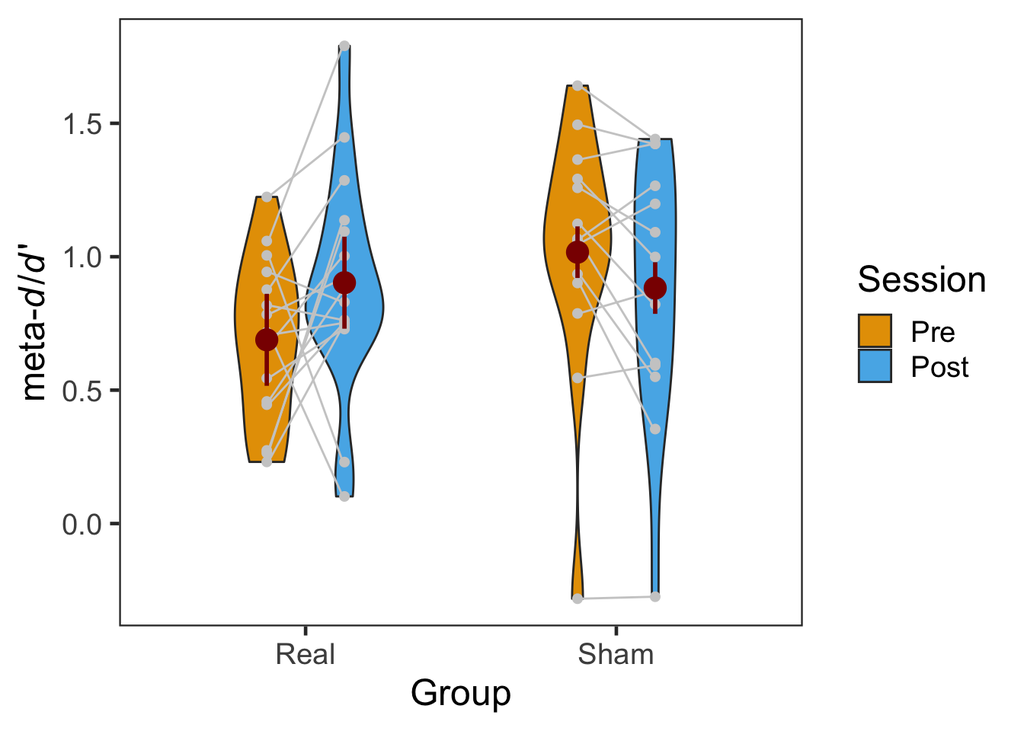

```r
tr %>% plot2x2spaghetti(ylabel = expression(paste("meta-", italic(d), "/", italic(d), "'")))
```

```r
tmp <- tr %>% aov_ez(id = 'SID', dv = 'V',
                     between = 'Group', within = 'Session',
                     anova_table = list(es = "pes"))
tmp %>% anova() %>% kable(digits = 4, caption = 'ANOVA')
```

ANOVA

|  | num Df | den Df | MSE | F | ges | Pr(>F) |
| --- | --- | --- | --- | --- | --- | --- |
| Group | 1 | 28 | 0.2833 | 1.2526 | 0.0347 | 0.2726 |
| Session | 1 | 28 | 0.0691 | 0.3437 | 0.0024 | 0.5624 |
| Group:Session | 1 | 28 | 0.0691 | 6.5589 | 0.0439 | 0.0161 |

```r
tmp2 <- tmp %>% emmeans::emmeans(pairwise ~ Session | Group)
tmp2$contrasts %>% kable(digits = 4, caption = 'Post hoc')
```

Post hoc

| contrast | Group | estimate | SE | df | t.ratio | p.value |
| --- | --- | --- | --- | --- | --- | --- |
| Pre - Post | Real | -0.2141 | 0.0929 | 28 | -2.3036 | 0.0289 |
| Pre - Post | Sham | 0.1343 | 0.0993 | 28 | 1.3520 | 0.1872 |

# 6 d’

```r
## d'
td <- mtb2 %>% selectMtb('p1da', 'p2da')

td %>% group_by(Group, Session) %>%
  summarise(M = mean(V)) %>%
  ungroup() %>%
  pivot_wider(names_from = 'Session', values_from = 'M') %>%
  kable(digits = 4, caption = 'Mean meta-d')
```

Mean meta-d

| Group | Pre | Post |
| --- | --- | --- |
| Real | 1.2115 | 1.1788 |
| Sham | 1.3662 | 1.2234 |

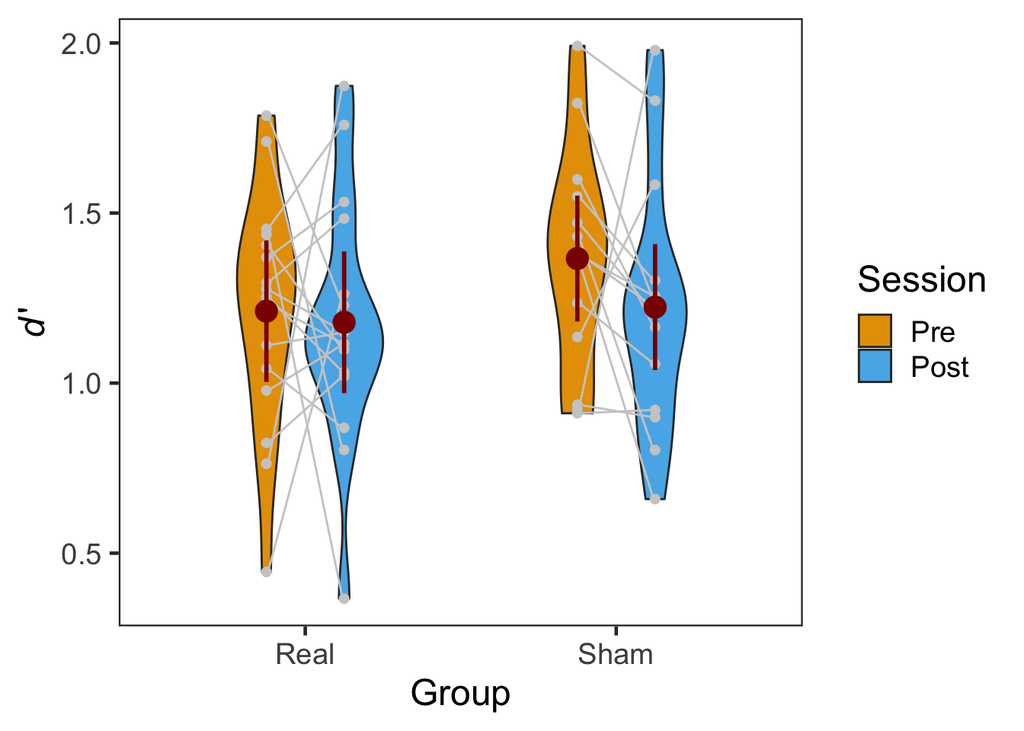

```r
td %>% plot2x2spaghetti(ylabel = expression(paste(italic(d), "'")))
```

```r
tmp <- td %>% aov_ez(id = 'SID', dv = 'V',
                     between = 'Group', within = 'Session',
                     anova_table = list(es = "pes"))
tmp %>% anova() %>% kable(digits = 4, caption = 'ANOVA')
```

ANOVA

|  | num Df | den Df | MSE | F | ges | Pr(>F) |
| --- | --- | --- | --- | --- | --- | --- |
| Group | 1 | 28 | 0.1192 | 1.2442 | 0.0209 | 0.2741 |
| Session | 1 | 28 | 0.1295 | 0.8871 | 0.0162 | 0.3543 |
| Group:Session | 1 | 28 | 0.1295 | 0.3488 | 0.0064 | 0.5595 |

```r
tmp2 <- tmp %>% emmeans::emmeans(pairwise ~ Session | Group)
tmp2$contrasts %>% kable(digits = 4, caption = 'Post hoc')
```

Post hoc

| contrast | Group | estimate | SE | df | t.ratio | p.value |
| --- | --- | --- | --- | --- | --- | --- |
| Pre - Post | Real | 0.0327 | 0.1272 | 28 | 0.2571 | 0.7990 |
| Pre - Post | Sham | 0.1427 | 0.1360 | 28 | 1.0492 | 0.3031 |

# 7 Meta-c

조건간 차이가 없었다.

```r
## Meta-c
tc <- mtb2 %>% selectMtb('p1meta_ca', 'p2meta_ca')

tc %>% group_by(Group, Session) %>%
  summarise(M = mean(V)) %>%
  ungroup() %>%
  pivot_wider(names_from = 'Session', values_from = 'M') %>%
  kable(digits = 4, caption = 'Mean meta-c')
```

Mean meta-c

| Group | Pre | Post |
| --- | --- | --- |
| Real | 0.2467 | 0.1340 |
| Sham | 0.3062 | 0.2367 |

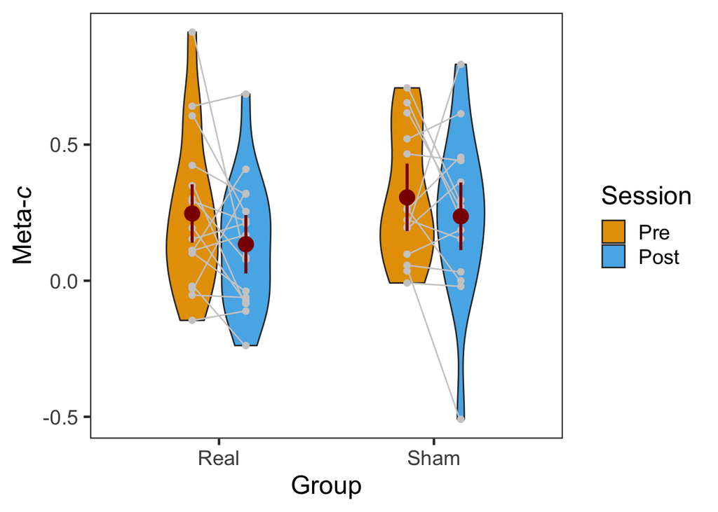

```r
tc %>% plot2x2spaghetti(ylabel = expression(paste("Meta-", italic(c))))
```

```r
tmp <- tc %>% aov_ez(id = 'SID', dv = 'V',
                     between = 'Group', within = 'Session',
                     anova_table = list(es = "pes"))
tmp %>% anova() %>% kable(digits = 4, caption = 'ANOVA')
```

ANOVA

|  | num Df | den Df | MSE | F | ges | Pr(>F) |
| --- | --- | --- | --- | --- | --- | --- |
| Group | 1 | 28 | 0.1044 | 0.9398 | 0.0232 | 0.3406 |
| Session | 1 | 28 | 0.0432 | 2.8720 | 0.0291 | 0.1012 |
| Group:Session | 1 | 28 | 0.0432 | 0.1610 | 0.0017 | 0.6913 |

```r
tmp2 <- tmp %>% emmeans::emmeans(pairwise ~ Session | Group)
tmp2$contrasts %>% kable(digits = 4, caption = 'Post hoc')
```

Post hoc

| contrast | Group | estimate | SE | df | t.ratio | p.value |
| --- | --- | --- | --- | --- | --- | --- |
| Pre - Post | Real | 0.1127 | 0.0735 | 28 | 1.5341 | 0.1362 |
| Pre - Post | Sham | 0.0696 | 0.0786 | 28 | 0.8856 | 0.3834 |

# 8 Meta-d’

```r
## meta-d'
tm <- mtb2 %>% selectMtb('p1meta_da', 'p2meta_da')

tm %>% group_by(Group, Session) %>%
  summarise(M = mean(V)) %>%
  ungroup() %>%
  pivot_wider(names_from = 'Session', values_from = 'M') %>%
  kable(digits = 4, caption = 'Mean meta-d')
```

Mean meta-d

| Group | Pre | Post |
| --- | --- | --- |
| Real | 0.8537 | 0.9993 |
| Sham | 1.3540 | 1.0626 |

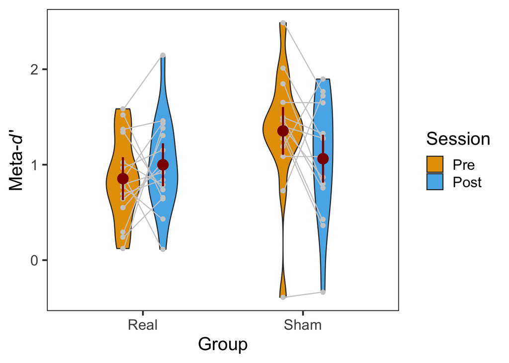

```r
tm %>% plot2x2spaghetti(ylabel = expression(paste("Meta-", italic(d), "'")))
```

```r
tmp <- tm %>% aov_ez(id = 'SID', dv = 'V',
                     between = 'Group', within = 'Session',
                     anova_table = list(es = "pes"))
tmp %>% anova() %>% kable(digits = 4, caption = 'ANOVA')
```

ANOVA

|  | num Df | den Df | MSE | F | ges | Pr(>F) |
| --- | --- | --- | --- | --- | --- | --- |
| Group | 1 | 28 | 0.4311 | 2.7511 | 0.0645 | 0.1083 |
| Session | 1 | 28 | 0.1833 | 0.4336 | 0.0046 | 0.5156 |
| Group:Session | 1 | 28 | 0.1833 | 3.8888 | 0.0398 | 0.0586 |

```r
tmp2 <- tmp %>% emmeans::emmeans(pairwise ~ Session | Group)
tmp2$contrasts %>% kable(digits = 4, caption = 'Post hoc')
```

Post hoc

| contrast | Group | estimate | SE | df | t.ratio | p.value |
| --- | --- | --- | --- | --- | --- | --- |
| Pre - Post | Real | -0.1455 | 0.1514 | 28 | -0.9614 | 0.3446 |
| Pre - Post | Sham | 0.2914 | 0.1618 | 28 | 1.8010 | 0.0825 |

# 9 Session Info

```r
sessionInfo()
## R version 4.0.5 (2021-03-31)
## Platform: x86_64-apple-darwin17.0 (64-bit)
## Running under: macOS Mojave 10.14.6
##
## Matrix products: default
## BLAS:   /Library/Frameworks/R.framework/Versions/4.0/Resources/lib/libRblas.dylib
## LAPACK: /Library/Frameworks/R.framework/Versions/4.0/Resources/lib/libRlapack.dylib
##
## locale:
## [1] en_US.UTF-8/en_US.UTF-8/en_US.UTF-8/C/en_US.UTF-8/en_US.UTF-8
##
## attached base packages:
## [1] stats     graphics  grDevices utils     datasets  methods   base
##
## other attached packages:
##  [1] metaSDT_0.5.0     klippy_0.0.0.9500 patchwork_1.1.1   emmeans_1.6.1
##  [5] afex_0.28-1       lme4_1.1-27       Matrix_1.3-4      ggpubr_0.4.0
##  [9] psych_2.1.3       knitr_1.33        forcats_0.5.1     stringr_1.4.0
## [13] dplyr_1.0.6       purrr_0.3.4       readr_1.4.0       tidyr_1.1.3
## [17] tibble_3.1.2      ggplot2_3.3.3     tidyverse_1.3.1
##
## loaded via a namespace (and not attached):
##  [1] ggbeeswarm_0.6.0    TH.data_1.0-10      minqa_1.2.4
##  [4] colorspace_2.0-1    ggsignif_0.6.2      ellipsis_0.3.2
##  [7] rio_0.5.26          estimability_1.3    fs_1.5.0
## [10] rstudioapi_0.13     farver_2.1.0        fansi_0.5.0
## [13] mvtnorm_1.1-2       lubridate_1.7.10    xml2_1.3.2
## [16] codetools_0.2-18    splines_4.0.5       mnormt_2.0.2
## [19] jsonlite_1.7.2      nloptr_1.2.2.2      broom_0.7.7
## [22] dbplyr_2.1.1        compiler_4.0.5      httr_1.4.2
## [25] backports_1.2.1     assertthat_0.2.1    cli_2.5.0
## [28] htmltools_0.5.1.1   tools_4.0.5         lmerTest_3.1-3
## [31] coda_0.19-4         gtable_0.3.0        glue_1.4.2
## [34] reshape2_1.4.4      Rcpp_1.0.6          carData_3.0-4
## [37] cellranger_1.1.0    jquerylib_0.1.4     vctrs_0.3.8
## [40] nlme_3.1-152        xfun_0.24           openxlsx_4.2.3
## [43] rvest_1.0.0         lifecycle_1.0.0     pacman_0.5.1
## [46] rstatix_0.7.0       nleqslv_3.3.2       MASS_7.3-54
## [49] zoo_1.8-9           scales_1.1.1        hms_1.1.0
## [52] parallel_4.0.5      sandwich_3.0-1      yaml_2.2.1
## [55] curl_4.3.1          sass_0.4.0          stringi_1.6.2
## [58] highr_0.9           boot_1.3-28         zip_2.2.0
## [61] rlang_0.4.11        pkgconfig_2.0.3     evaluate_0.14
## [64] lattice_0.20-44     labeling_0.4.2      tidyselect_1.1.1
## [67] plyr_1.8.6          magrittr_2.0.1      R6_2.5.0
## [70] generics_0.1.0      multcomp_1.4-17     DBI_1.1.1
## [73] pillar_1.6.1        haven_2.4.1         foreign_0.8-81
## [76] withr_2.4.2         survival_3.2-11     abind_1.4-5
## [79] modelr_0.1.8        crayon_1.4.1        car_3.0-10
## [82] utf8_1.2.1          tmvnsim_1.0-2       rmarkdown_2.9
## [85] grid_4.0.5          readxl_1.3.1        data.table_1.14.0
## [88] reprex_2.0.0        digest_0.6.27       xtable_1.8-4
## [91] numDeriv_2016.8-1.1 munsell_0.5.0       beeswarm_0.4.0
## [94] vipor_0.4.5         bslib_0.2.5.1
```